# EAI Tutorial 3.4

## The Principles of Tidy Data

Most datasets are data frames made up of **rows** and **columns**. The columns are almost always labeled and the rows are sometimes labeled.

```r
library(tidyverse)
library(magrittr)

#Set working directory, so you do not need to repeat long paths.
setwd("~/Elements of AI/Labs/Data/FIFA.22.Original.Data/")
data <- read_csv("players_22.csv", col_names = TRUE, num_threads = 4)
data %<>% select(short_name, dob, starts_with("skill")) %>%
   slice(1:5)
data
```

```
## # A tibble: 5 × 8
##   short_name        dob        skill_moves skill_dribbling skill_curve
##   <chr>             <date>           <dbl>           <dbl>       <dbl>
## 1 L. Messi          1987-06-24           4              96          93
## 2 R. Lewandowski    1988-08-21           4              85          79
## 3 Cristiano Ronaldo 1985-02-05           5              88          81
## 4 Neymar Jr         1992-02-05           5              95          88
## 5 K. De Bruyne      1991-06-28           4              88          85
## # ℹ 3 more variables: skill_fk_accuracy <dbl>, skill_long_passing <dbl>,
## #   skill_ball_control <dbl>
```

### Data Loading

As code suggests, you can load most rectangular data formats (tsv, csv, txt,, etc.) using **read_*** functions from **Tidyverse**. Tidyverse is an opinionated collection of R packages designed for data manipulation, functional programming and data visualization. All packages share an underlying design philosophy, grammar, and data structures.

You need not to be familiar with different Tidyverse packages, because once you load tidyverse with `library(tidyverse)`, all necessary tools are provided[^1]. Tidyverse collection can be installed with `install.packages("tidyverse")`. To load data into R, we will simply call `read_csv()` and provide the file name and the location from which that file should be read.

**Task 1:** Think about data you have just loaded. Is there anything wrong with their arrangement? If so, what is it?

**Task 2:** Load `Practicum.2.Data.1.csv` with `read_csv()` and `read.csv()`. `read.csv()` is a default csv loading function implemented in the `base` package. Inspect data loaded in R and look for differences. I should not tell you, but you want to focus on behavior of sentinel values and cells containing text.

**Task 3:** There are more than one way to structure the same data. The following table shows `players` data as above, but the rows and columns have been transposed. Are both versions equal? Or is one of them more correct in terms of …? What do you think? Try to come up with supporting evidence of your reasoning.

```
## # A tibble: 6 × 6
##   skill              `L. Messi` `R. Lewandowski` `Cristiano Ronaldo` `Neymar Jr`
##   <chr>                   <dbl>            <dbl>               <dbl>       <dbl>
## 1 skill_moves                 4                4                   5           5
## 2 skill_dribbling            96               85                  88          95
## 3 skill_curve                93               79                  81          88
## 4 skill_fk_accuracy          94               85                  84          87
## 5 skill_long_passing         91               70                  77          81
## 6 skill_ball_control         96               88                  88          95
## # ℹ 1 more variable: `K. De Bruyne` <dbl>
```

### Data Semantics

The data is the same, but the layout is different. Our vocabulary of rows and columns is simply not rich enough to describe why the two tables represent the same data. In addition to appearance, we need a way to describe the underlying semantics, or meaning, of the values displayed in the table. This can be set up as follows.

A dataset is a collection of values, where every value must belong to a **variable** and an **observation**. A **variable** contains all values that measure the same underlying attribute (like name, date-of-birth, height, wage) across units. An **observation** contains all values measured on the same unit (like a player, or a name) across attributes.

**Task 4:** Rethink an initial arrangement of `players` data. Do they conform to data semantics we have just outlined? Which key assumptions they invalidate?

You may have noticed that *date of birth* variable — or dob — contains three values for single variable, thus conflicting assumption that a variable has exactly one.

The second problem is a bit more elusive, but stays within the definition of **variable**. For a given dataset, it’s usually easy to figure out what are observations and what are variables, but it is surprisingly difficult to precisely define variables and observations in general.

For example, if the columns in the player data were `moves` , `dribbling` and `curve`, you would have been happy to call them variables. If the columns were `skill_moves` and `skill_dribbling`, you could treat these as two variables, but in an exploratory setting we might want variables `skill_value` and `skill_type` because that’s often what machine learning and plotting functions require.

We can now summarize both problems graphically:

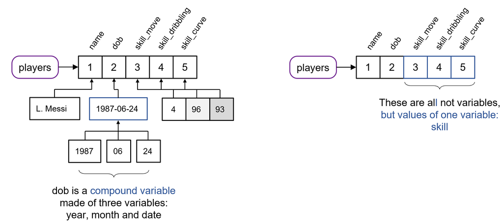

**Task 5:** Now you know what the problems are, conceptualize the steps needed to convert `players` into a format that conforms to data semantics. How many transformation steps would you need?